# TEST Global-Restore-Project GOE DataViz

### 4.5.2 GRP_Site_data

**Click open to see `GRP_Site_data`**

```r
GRP_Site_data
```

```
##     siteid projectid                                 Site Subregion
## 1        1         1                          Albert Head      C-SP
## 2        2         1                         Alec Rocks 1     US-GI
## 3        3         1                         Alec Rocks 2     US-GI
## 4        4         1                        Amelia Island    C-EVII
## 5        5         1                    Battleship Island     US-GI
## 6        6         1                          Bear Hill A      C-SP
## 7        7         1                          Bear Hill B      C-SP
## 8        8         1                          Bear Hill C      C-SP
## 9        9         1                       Boulder Island     US-GI
## 10      10         1                        Boulderwood E      C-SP
## 11      11         1                        Boulderwood W      C-SP
## 12      12         1              Brackman Island Patch 1      C-GI
## 13      13         1              Brackman Island Patch 2      C-GI
## 14      14         1                           Cairn Park      C-SP
```

[output cut: 813 more lines]

### 4.5.3 Sites: Save chosen columns as csv to input into Shiny drop down list of Sites

```r
write.csv(GRP_Site_data, "data/GRP_Site_data.csv", row.names = FALSE)
```

# SQL Create Database

```r
# https://www.youtube.com/watch?v=c3e8m3K0eC4
#
# install.packages("RSQL")
# install.packages("RSQLite")
# install.packages("tidyverse") # v.1.3.2 to 2.0.0
library(RSQL)
library(RSQLite)
library(tidyverse)
# tidyverse_packages(include_self = TRUE)
```

```r
# ## Tidyverse db ex
# data("population")
# population
#
# data("who")
# who
```

```r
# ### create database and connection
# # builds empty db in R memory
# con <- dbConnect(drv = RSQLite::SQLite(),
#                  dbname = ":memory:")
# dbListTables(con)
```

```r
### Populate tables
# - dbWriteTable
#
# # Load population table
# dbWriteTable(conn = con,
#              name = "population",
#              value = population)
# str(population)
#
# # Load population table
# dbWriteTable(conn = con,
#              name = "who",
#              value = who)
# str(who)
#
# #remove the local data from the environment
# rm(who, population)
# dbListTables(con)
```

```r
# ### Query for db
# res <- DBI::dbGetQuery(conn = con,
#          statement = "
#          SELECT who.country, who.year, who.new_sp_m014, population.population
#          FROM population, who
#          WHERE who.country = 'Afghanistan' AND
#          who.year > 1995 AND
#          who.country = population.country AND
#          who.year = population.year
#          ")
# res
```

## 4.6 GRP Database

### 4.6.1 create GRP database and connection

```r
# builds empty db in R memory
con <- dbConnect(drv = RSQLite::SQLite(),
                 dbname = ":memory:")
dbListTables(con)
```

```
## character(0)
```

### 4.6.2 Populate GRP tables

- dbWriteTable

```r
# Load OM_veg_1_5 table
dbWriteTable(conn = con,
             name = "OM_veg_1_5",
             value = OM_veg_1_5)
str(OM_veg_1_5)
```

```
## 'data.frame':    136364 obs. of  14 variables:
##  $ id               : chr  "OM_1" "OM_1" "OM_1" "OM_1" ...
##  $ DB               : chr  "OM" "OM" "OM" "OM" ...
##  $ treatmentid      : chr  "1_1" "1_1" "1_1" "1_1" ...
##  $ year             : int  2008 2008 2008 2008 2008 2008 2008 2008 2008 2008 ...
##  $ tsr              : int  122 122 122 122 122 122 122 122 122 122 ...
##  $ block            : int  NA NA NA NA NA NA NA NA NA NA ...
##  $ replicate        : int  2 2 2 2 3 3 3 3 3 3 ...
##  $ speciesid        : chr  "Ant_odo" "Hyp_rad" "Que_gar" "Sed_spa" ...
##  $ speciesorigin    : chr  "exotic" "exotic" "native" "native" ...
##  $ response         : num  15.8 3.8 0.2 0.1 0.2 14.2 1.4 7.3 0.4 0.4 ...
##  $ responselevel    : chr  "species" "species" "species" "species" ...
##  $ responsemetric   : chr  "cover" "cover" "cover" "cover" ...
##  $ measurementscale : chr  "1" "1" "1" "1" ...
##  $ measurementmetric: chr  "m2" "m2" "m2" "m2" ...
```

```r
# Load OM_site_data table
dbWriteTable(conn = con,
             name = "OM_site_data",
             value = OM_site_data)
str(OM_site_data)
```

```
## 'data.frame':    206 obs. of  50 variables:
##  $ DB                : chr  "OM" "OM" "OM" "OM" ...
##  $ siteid            : int  1 2 3 4 5 6 7 8 9 10 ...
##  $ projectid         : int  1 1 1 1 1 1 1 1 1 1 ...
##  $ Site              : chr  "Albert Head" "Alec Rocks 1" "Alec Rocks 2" "Amelia Island" ...
##  $ Subregion         : chr  "C-SP" "US-GI" "US-GI" "C-EVII" ...
##  $ Subregion.an      : chr  "a1" "a2" "a3" "a4" ...
##  $ latitude          : num  48.4 48.4 48.4 49.3 48.6 ...
##  $ longitude         : num  -123 -123 -123 -124 -123 ...
##  $ refecosystem      : chr  "garry oak meadow" "garry oak meadow" "garry oak meadow" "garry oak meadow" ...
##  $ USDA.class        : chr  "1_forest and woodland" "1_forest and woodland" "1_forest and woodland" "1_forest and woodland" ...
##  $ USDA.subclass     : chr  "1b_temperate and boreal forest and woodland" "1b_temperate and boreal forest and woodland" "1b_temperate and boreal forest and woodland" "1b_temperate and boreal forest and woodland" ...
##  $ USDA.subsubclass  : chr  "1b2_cool temperate forest and woodland" "1b2_cool temperate forest and woodland" "1b2_cool temperate forest and woodland" "1b2_cool temperate forest and woodland" ...
##  $ landcover         : chr  "w" "w" "w" "w" ...
##  $ growingseasonstart: logi  NA NA NA NA NA NA ...
```

[output cut: 36 more lines]

```r
# Load OM_treatments_data table
dbWriteTable(conn = con,
             name = "OM_treatments_data",
             value = OM_treatments_data)
str(OM_treatments_data)
```

```
## 'data.frame':    2653 obs. of  17 variables:
##  $ DB                : chr  "OM" "OM" "OM" "OM" ...
##  $ treatmentid       : chr  "1_1" "1_10" "1_11" "1_12" ...
##  $ siteid            : int  1 10 11 12 13 14 15 16 17 18 ...
##  $ restorationtype   : chr  "reference" "reference" "reference" "reference" ...
##  $ tsr_start_year    : int  NA NA NA NA NA NA NA NA NA NA ...
##  $ trt_year          : int  NA NA NA NA NA NA NA NA NA NA ...
##  $ trt_tsr           : int  NA NA NA NA NA NA NA NA NA NA ...
##  $ disturbanceendyear: logi  NA NA NA NA NA NA ...
##  $ treatmentmonth    : int  NA NA NA NA NA NA NA NA NA NA ...
##  $ treatmentday      : logi  NA NA NA NA NA NA ...
##  $ topsoilage        : logi  NA NA NA NA NA NA ...
##  $ othertreatments   : logi  NA NA NA NA NA NA ...
##  $ treatment_category: chr  "application method" "application method" "application method" "application method" ...
##  $ treatment_type    : chr  "none" "none" "none" "none" ...
##  $ treatment_amount  : chr  "applied" "applied" "applied" "applied" ...
##  $ treatment_units   : chr  "treatment presence" "treatment presence" "treatment presence" "treatment presence" ...
##  $ X                 : logi  NA NA NA NA NA NA ...
```

```r
dbListTables(con)
```

```
## [1] "OM_site_data"       "OM_treatments_data" "OM_veg_1_5"
```

## 4.7 Preview tables

```r
tbl(src = con, "OM_site_data")
```

```
## # Source:   table<OM_site_data> [?? x 50]
## # Database: sqlite 3.44.2 [:memory:]
##    DB    siteid projectid Site         Subregion Subregion.an latitude longitude
##    <chr>  <int>     <int> <chr>        <chr>     <chr>           <dbl>     <dbl>
##  1 OM         1         1 Albert Head  C-SP      a1               48.4     -123.
##  2 OM         2         1 Alec Rocks 1 US-GI     a2               48.4     -123.
##  3 OM         3         1 Alec Rocks 2 US-GI     a3               48.4     -123.
##  4 OM         4         1 Amelia Isla… C-EVII    a4               49.3     -124.
##  5 OM         5         1 Battleship … US-GI     a5               48.6     -123.
##  6 OM         6         1 Bear Hill A  C-SP      a6               48.5     -123.
##  7 OM         7         1 Bear Hill B  C-SP      a7               48.5     -123.
##  8 OM         8         1 Bear Hill C  C-SP      a8               48.5     -123.
##  9 OM         9         1 Boulder Isl… US-GI     a9               48.4     -123.
## 10 OM        10         1 Boulderwood… C-SP      a10              48.5     -123.
## # ℹ more rows
## # ℹ 42 more variables: refecosystem <chr>, USDA.class <chr>,
## #   USDA.subclass <chr>, USDA.subsubclass <chr>, landcover <chr>,
## #   growingseasonstart <int>, growingseasonend <int>, sand <int>, silt <int>,
## #   clay <int>, soildescription <int>, soildepth <int>, elevation <int>,
## #   aspect <dbl>, slope <dbl>, precipc <int>, tempc <int>, aridity <dbl>,
## #   temp <dbl>, drange <dbl>, iso <dbl>, tseason <dbl>, mtwarm <dbl>, …
```

```r
tbl(src = con, "OM_treatments_data")
```

```
## # Source:   table<OM_treatments_data> [?? x 17]
## # Database: sqlite 3.44.2 [:memory:]
##    DB    treatmentid siteid restorationtype tsr_start_year trt_year trt_tsr
##    <chr> <chr>        <int> <chr>                    <int>    <int>   <int>
##  1 OM    1_1              1 reference                   NA       NA      NA
##  2 OM    1_10            10 reference                   NA       NA      NA
##  3 OM    1_11            11 reference                   NA       NA      NA
##  4 OM    1_12            12 reference                   NA       NA      NA
##  5 OM    1_13            13 reference                   NA       NA      NA
##  6 OM    1_14            14 reference                   NA       NA      NA
##  7 OM    1_15            15 reference                   NA       NA      NA
##  8 OM    1_16            16 reference                   NA       NA      NA
##  9 OM    1_17            17 reference                   NA       NA      NA
## 10 OM    1_18            18 reference                   NA       NA      NA
## # ℹ more rows
## # ℹ 10 more variables: disturbanceendyear <int>, treatmentmonth <int>,
## #   treatmentday <int>, topsoilage <int>, othertreatments <int>,
## #   treatment_category <chr>, treatment_type <chr>, treatment_amount <chr>,
## #   treatment_units <chr>, X <int>
```

```r
tbl(src = con, "OM_veg_1_5")
```

```
## # Source:   table<OM_veg_1_5> [?? x 14]
## # Database: sqlite 3.44.2 [:memory:]
##    id    DB    treatmentid  year   tsr block replicate speciesid speciesorigin
##    <chr> <chr> <chr>       <int> <int> <int>     <int> <chr>     <chr>
##  1 OM_1  OM    1_1          2008   122    NA         2 Ant_odo   exotic
##  2 OM_1  OM    1_1          2008   122    NA         2 Hyp_rad   exotic
##  3 OM_1  OM    1_1          2008   122    NA         2 Que_gar   native
##  4 OM_1  OM    1_1          2008   122    NA         2 Sed_spa   native
##  5 OM_1  OM    1_1          2008   122    NA         3 Air_pra   exotic
##  6 OM_1  OM    1_1          2008   122    NA         3 Ant_odo   exotic
##  7 OM_1  OM    1_1          2008   122    NA         3 Bro_cor_a native
##  8 OM_1  OM    1_1          2008   122    NA         3 Bro_hor   exotic
##  9 OM_1  OM    1_1          2008   122    NA         3 Bro_rig   exotic
## 10 OM_1  OM    1_1          2008   122    NA         3 Cla_per   native
## # ℹ more rows
## # ℹ 5 more variables: response <dbl>, responselevel <chr>,
## #   responsemetric <chr>, measurementscale <chr>, measurementmetric <chr>
```

## 4.8 Query for db

### 4.8.1 1-Results query one tables

```sql
SELECT *
FROM OM_site_data
WHERE projectid = 1
```

#### 4.8.1.1 View query results

**Click open to see R code for `query results`**

```r
results_projid
```

```
##    DB siteid projectid                      Site Subregion Subregion.an
## 1  OM      1         1               Albert Head      C-SP           a1
## 2  OM      2         1              Alec Rocks 1     US-GI           a2
## 3  OM      3         1              Alec Rocks 2     US-GI           a3
## 4  OM      4         1             Amelia Island    C-EVII           a4
## 5  OM      5         1         Battleship Island     US-GI           a5
## 6  OM      6         1               Bear Hill A      C-SP           a6
## 7  OM      7         1               Bear Hill B      C-SP           a7
## 8  OM      8         1               Bear Hill C      C-SP           a8
## 9  OM      9         1            Boulder Island     US-GI           a9
## 10 OM     10         1             Boulderwood E      C-SP          a10
## 11 OM     11         1             Boulderwood W      C-SP          a11
## 12 OM     12         1   Brackman Island Patch 1      C-GI          a12
## 13 OM     13         1   Brackman Island Patch 2      C-GI          a13
## 14 OM     14         1                Cairn Park      C-SP          a14
```

[output cut: 858 more lines]

### 4.8.2 2-Results query two tables

```sql
SELECT s.siteid, t.treatmentid, s.Site
FROM OM_site_data AS s
INNER JOIN OM_treatments_data AS t ON s.siteid = t.siteid
WHERE projectid = 1
```

#### 4.8.2.1 View query results

**Click open to see R code for `query results`**

```r
results_projid_2
```

```
##    siteid treatmentid                      Site
## 1       1         1_1               Albert Head
## 2       2         1_2              Alec Rocks 1
## 3       3         1_3              Alec Rocks 2
## 4       4         1_4             Amelia Island
## 5       5         1_5         Battleship Island
## 6       6         1_6               Bear Hill A
## 7       7         1_7               Bear Hill B
## 8       8         1_8               Bear Hill C
## 9       9         1_9            Boulder Island
## 10     10        1_10             Boulderwood E
## 11     11        1_11             Boulderwood W
## 12     12        1_12   Brackman Island Patch 1
## 13     13        1_13   Brackman Island Patch 2
## 14     14        1_14                Cairn Park
```

[output cut: 82 more lines]

```r
# OM_veg_1_5: treatmentid
# OM_site_data: siteid   sitename
# OM_treatments_data: treatmentid   siteid
# <!--
# # SELECT who.country, who.year, who.new_sp_m014, population.population -->
# <!-- #          FROM population, who -->
# <!-- #          WHERE who.country = 'Afghanistan' AND  -->
# <!-- #          who.year > 1995 AND -->
# <!-- #          who.country = population.country AND -->
# <!-- #          who.year = population.year -->
#
# SELECT OM_site_data.siteid, OM_site_data.sitename, OM_treatments_data.treatmentid, OM_treatments_data.siteid, OM_veg_1_5.treatmentid, OM_treatments_data.restorationtype, OM_veg_1_5.year
# FROM OM_veg_1_5, OM_site_data, OM_treatments_data
# LEFT JOIN OM_site_data ON OM_site_data.siteid = OM_treatments_data.siteid AND OM_veg_1_5.treatmentid = OM_veg_1_5.treatmentid
# WHERE OM_treatments_data.restorationtype = 'seeding' AND OM_veg_1_5.year = 2005
```

### 4.8.3 3-Results query three tables - one species & 1 year

- SELECT DISTINCT for no duplicates

```sql
SELECT DISTINCT s.siteid, t.treatmentid, s.Site, v.year, v.speciesid
FROM OM_site_data AS s
INNER JOIN OM_treatments_data AS t ON s.siteid = t.siteid
INNER JOIN OM_veg_1_5 AS v ON t.treatmentid = v.treatmentid
WHERE speciesid = "Ant_odo" AND year = 2008
```

#### 4.8.3.1 View query results

**Click open to see R code for `query results`**

```r
results_projid_3
```

```
##     siteid treatmentid                    Site year speciesid
## 1        1         1_1             Albert Head 2008   Ant_odo
## 2       10        1_10           Boulderwood E 2008   Ant_odo
## 3       11        1_11           Boulderwood W 2008   Ant_odo
## 4       12        1_12 Brackman Island Patch 1 2008   Ant_odo
## 5       13        1_13 Brackman Island Patch 2 2008   Ant_odo
## 6       17        1_17   Channel Middle Island 2008   Ant_odo
## 7       19        1_19          Christmas Hill 2008   Ant_odo
## 8       21        1_21                  Dean E 2008   Ant_odo
## 9       22        1_22                  Dean P 2008   Ant_odo
## 10      23        1_23                  Dean W 2008   Ant_odo
## 11      24        1_24           Dock Island N 2008   Ant_odo
## 12      25        1_25           Dock Island S 2008   Ant_odo
## 13      28        1_28          Francis King N 2008   Ant_odo
## 14      29        1_29          Francis King S 2008   Ant_odo
```

[output cut: 162 more lines]

### 4.8.4 3-Results query three tables - one Site

- SELECT DISTINCT for no duplicates

```sql
SELECT DISTINCT s.siteid, s.Site, s.Subregion, t.treatmentid, v.year, v.speciesid, v.tsr, v.replicate, v.response
FROM OM_site_data AS s
INNER JOIN OM_treatments_data AS t ON s.siteid = t.siteid
INNER JOIN OM_veg_1_5 AS v ON t.treatmentid = v.treatmentid
WHERE Site = "Christmas Hill"
```

#### 4.8.4.1 View query results

**Click open to see R code for `query results`**

```r
results_projid_4
```

```
##     siteid           Site Subregion treatmentid year   speciesid tsr replicate
## 1       19 Christmas Hill      C-SP        1_19 2006     Ach_mil   0         1
## 2       19 Christmas Hill      C-SP        1_19 2006     Air_car   0         1
## 3       19 Christmas Hill      C-SP        1_19 2006     Air_pra   0         1
## 4       19 Christmas Hill      C-SP        1_19 2006    Alli_acu   0         1
## 5       19 Christmas Hill      C-SP        1_19 2006     Ame_aln   0         1
## 6       19 Christmas Hill      C-SP        1_19 2006     Ant_cau   0         1
## 7       19 Christmas Hill      C-SP        1_19 2006     Ant_odo   0         1
## 8       19 Christmas Hill      C-SP        1_19 2006     Arc_uva   0         1
## 9       19 Christmas Hill      C-SP        1_19 2006     Arr_ela   0         1
## 10      19 Christmas Hill      C-SP        1_19 2006     Ave_fat   0         1
## 11      19 Christmas Hill      C-SP        1_19 2006     Bar_ort   0         1
## 12      19 Christmas Hill      C-SP        1_19 2006     Bel_per   0         1
## 13      19 Christmas Hill      C-SP        1_19 2006     Ber_aqu   0         1
## 14      19 Christmas Hill      C-SP        1_19 2006   Bro_cor_a   0         1
```

[output cut: 481 more lines]

### 4.8.5 3-Results query three tables - all Sites

- SELECT DISTINCT for no duplicates
- should be 196 sites - not showing ones with same Sitename but different siteid
- include t.siteid to see that the correspondence works
- should be 196 sites (query results 149)
- WHERE s.DB = “OM”

```sql
SELECT DISTINCT s.siteid, s.projectid, s.Site, s.Subregion, s.temp, s.precip, s.latitude, s.longitude, s.refecosystem, s.landcover, s.elevation, s.aspect
FROM OM_site_data AS s
INNER JOIN OM_treatments_data AS t ON s.siteid = t.siteid
INNER JOIN OM_veg_1_5 AS v ON t.treatmentid = v.treatmentid
WHERE s.siteid BETWEEN 1 AND 196
```

#### 4.8.5.1 View query results

- this doesn’t have all sites, and some duplicate siteid

**Click open to see R code for `query results`**

```r
results_projid_5
```

```
##     siteid projectid                      Site Subregion temp precip latitude
## 1        1         1               Albert Head      C-SP 10.3    810 48.39111
## 2        2         1              Alec Rocks 1     US-GI  9.9    585 48.42301
## 3        3         1              Alec Rocks 2     US-GI  9.9    585 48.42247
## 4        4         1             Amelia Island    C-EVII  9.1   1284 49.30286
## 5        5         1         Battleship Island     US-GI 10.1    702 48.62453
## 6        6         1               Bear Hill A      C-SP  9.8    890 48.54631
## 7        7         1               Bear Hill B      C-SP  9.8    890 48.54610
## 8        8         1               Bear Hill C      C-SP  9.8    890 48.54574
## 9        9         1            Boulder Island     US-GI 10.1    584 48.43249
## 10      10         1             Boulderwood E      C-SP  9.8    890 48.50535
## 11      11         1             Boulderwood W      C-SP  9.8    890 48.50545
## 12      12         1   Brackman Island Patch 1      C-GI  9.5    995 48.71802
## 13      13         1   Brackman Island Patch 2      C-GI  9.5    995 48.71976
## 14      14         1                Cairn Park      C-SP 10.3    810 48.43476
```

[output cut: 285 more lines]

#### 4.8.5.2 Save query as csv file with all Site inof

```r
write.csv(results_projid_5, "data/GRP_all_site_data.csv", row.names = FALSE)
```

### 4.8.6 ?? 3-Results query three tables - all Sites - still not showing all

```sql
SELECT s.siteid, s.projectid, s.Site, s.Subregion, s.latitude, s.longitude, s.refecosystem, s.landcover, s.elevation, s.aspect, s.slope, s.temp, s.precip, s.disturbance
FROM OM_site_data AS s
WHERE s.DB = "OM"
```

#### 4.8.6.1 View query results

- this doesn’t have all sites, and some duplicate siteid

**Click open to see R code for `query results`**

```r
results_projid_6
```

```
##     siteid projectid                                 Site Subregion latitude
## 1        1         1                          Albert Head      C-SP 48.39111
## 2        2         1                         Alec Rocks 1     US-GI 48.42301
## 3        3         1                         Alec Rocks 2     US-GI 48.42247
## 4        4         1                        Amelia Island    C-EVII 49.30286
## 5        5         1                    Battleship Island     US-GI 48.62453
## 6        6         1                          Bear Hill A      C-SP 48.54631
## 7        7         1                          Bear Hill B      C-SP 48.54610
## 8        8         1                          Bear Hill C      C-SP 48.54574
## 9        9         1                       Boulder Island     US-GI 48.43249
## 10      10         1                        Boulderwood E      C-SP 48.50535
## 11      11         1                        Boulderwood W      C-SP 48.50545
## 12      12         1              Brackman Island Patch 1      C-GI 48.71802
## 13      13         1              Brackman Island Patch 2      C-GI 48.71976
## 14      14         1                           Cairn Park      C-SP 48.43476
```

[output cut: 606 more lines]

```r
length(unique(results_projid_6$Site))
```

```
## [1] 201
```

#### 4.8.6.2 Save query as csv file with all 206 Sites

```r
write.csv(results_projid_6, "data/GRP_all_site_data_sql.csv", row.names = FALSE)
```

### 4.8.7 7 Query Results Treatment + Sites

- dataframe *add Site & Subregion* to *treatment and species df*
- `results_projid_7` R observation rows: 1,961,307
- Excel maximum rows 1,048,576

```sql
SELECT s.siteid, s.projectid, s.Site, s.Subregion, t.treatmentid, t.restorationtype, t.tsr_start_year, t.trt_year, t.treatmentmonth, t.treatment_category, t.treatment_type
FROM OM_treatments_data AS t
INNER JOIN OM_site_data AS s ON t.siteid = s.siteid
INNER JOIN OM_veg_1_5 AS v ON t.treatmentid = v.treatmentid
WHERE s.DB = "OM"
```

#### 4.8.7.1 View query results

- Query Results Treatment + Sites

**Click open to see R code for `query results`**

```r
results_projid_7
```

```
##      siteid projectid                      Site Subregion treatmentid
## 1         1         1               Albert Head      C-SP         1_1
## 2         1         1               Albert Head      C-SP         1_1
## 3         1         1               Albert Head      C-SP         1_1
## 4         1         1               Albert Head      C-SP         1_1
## 5         1         1               Albert Head      C-SP         1_1
## 6         1         1               Albert Head      C-SP         1_1
## 7         1         1               Albert Head      C-SP         1_1
## 8         1         1               Albert Head      C-SP         1_1
## 9         1         1               Albert Head      C-SP         1_1
## 10        1         1               Albert Head      C-SP         1_1
## 11        1         1               Albert Head      C-SP         1_1
## 12        1         1               Albert Head      C-SP         1_1
## 13        1         1               Albert Head      C-SP         1_1
## 14        1         1               Albert Head      C-SP         1_1
```

[output cut: 27259 more lines]

#### 4.8.7.2 Save query as csv file

- Query Results Treatment + Sites
- `results_projid_7` R observation rows: 1,961,307
- Excel maximum rows 1,048,576 … too large to view in Excel

```r
write.csv(results_projid_7, "data/GRP-Site-Treatment-SQL.csv", row.names = FALSE)
```

### 4.8.8 8 Query Results Treatment + Sites

- dataframe *add Site & Subregion* to *treatment and species df*
- `results_projid_7` R observation rows: 1,961,307
- Excel maximum rows 1,048,576
- WHERE s.Subregion = “US-GI” >>> change Subregion and save csv for each
- US-GI, US-Oreg, US-Wash, C-GI, C-EVI, C-EVII, C-SP
- add year from v.year as some treatments done include year start end

```sql
SELECT s.siteid, s.projectid, s.Site, s.Subregion, t.treatmentid, t.restorationtype, t.tsr_start_year, t.trt_year, t.treatmentmonth, t.treatment_category, t.treatment_type
FROM OM_treatments_data AS t
INNER JOIN OM_site_data AS s ON t.siteid = s.siteid
INNER JOIN OM_veg_1_5 AS v ON t.treatmentid = v.treatmentid
WHERE s.Subregion = "C-SP"
```

#### 4.8.8.1 View query results

- Query Results Treatment + Sites

**Click open to see R code for `query results`**

```r
results_projid_8
```

```
##      siteid projectid                      Site Subregion treatmentid
## 1         1         1               Albert Head      C-SP         1_1
## 2         1         1               Albert Head      C-SP         1_1
## 3         1         1               Albert Head      C-SP         1_1
## 4         1         1               Albert Head      C-SP         1_1
## 5         1         1               Albert Head      C-SP         1_1
## 6         1         1               Albert Head      C-SP         1_1
## 7         1         1               Albert Head      C-SP         1_1
## 8         1         1               Albert Head      C-SP         1_1
## 9         1         1               Albert Head      C-SP         1_1
## 10        1         1               Albert Head      C-SP         1_1
## 11        1         1               Albert Head      C-SP         1_1
## 12        1         1               Albert Head      C-SP         1_1
## 13        1         1               Albert Head      C-SP         1_1
## 14        1         1               Albert Head      C-SP         1_1
```

[output cut: 27259 more lines]

#### 4.8.8.2 Save query as csv file

- Query Results Treatment + Sites

```r
write.csv(results_projid_8, "data/GRP-Site-Treatment-SQL-C-SP.csv", row.names = FALSE)
```

### 4.8.9 9 Query Results Species + Sites

- dataframe *add Site & Subregion* to *treatment and species df*
- `results_projid_7` R observation rows: 1,961,307
- Excel maximum rows 1,048,576
- WHERE s.Subregion = “US-GI” >>> change Subregion and save csv for each
- US-GI, US-Oreg, US-Wash, C-GI, C-EVI, C-EVII, C-SP

```sql
SELECT s.siteid, s.projectid, s.Site, s.Subregion, v.treatmentid, v.year AS "v_year_measure", v.replicate, v.speciesid, v.speciesorigin, v.response, v.responselevel, v.responsemetric, v.measurementscale, v.measurementmetric
FROM OM_veg_1_5 AS v
INNER JOIN OM_site_data AS s ON t.siteid = s.siteid
INNER JOIN OM_treatments_data AS t  ON v.treatmentid = t.treatmentid
WHERE s.Subregion = "US-Wash"
```

#### 4.8.9.1 View query results

- Query Results Treatment + Sites

**Click open to see R code for `query results`**

```r
results_projid_9
```

```
##      siteid projectid    Site Subregion treatmentid v_year_measure replicate
## 1       128         4 AuSable   US-Wash         4_1           2006         1
## 2       128         4 AuSable   US-Wash         4_1           2006         1
## 3       128         4 AuSable   US-Wash         4_1           2006         1
## 4       128         4 AuSable   US-Wash         4_1           2006         1
## 5       128         4 AuSable   US-Wash         4_1           2006         1
## 6       128         4 AuSable   US-Wash         4_1           2006         1
## 7       128         4 AuSable   US-Wash         4_1           2006         1
## 8       128         4 AuSable   US-Wash         4_1           2006         1
## 9       128         4 AuSable   US-Wash         4_1           2006         1
## 10      128         4 AuSable   US-Wash         4_1           2006         1
## 11      128         4 AuSable   US-Wash         4_1           2006         1
## 12      128         4 AuSable   US-Wash         4_1           2006         1
## 13      128         4 AuSable   US-Wash         4_1           2006         1
## 14      128         4 AuSable   US-Wash         4_1           2006         1
```

[output cut: 21415 more lines]

#### 4.8.9.2 Save query as csv file

- Query Results Treatment + Sites

```r
write.csv(results_projid_9, "data/GRP-Site-SpeciesCover-SQL-US-Wash.csv", row.names = FALSE)
```

### 4.8.10 10 Query Results Species + Sites

- dataframe *add Site & Subregion* to *treatment and species df*
- `results_projid_7` R observation rows: 1,961,307
- Excel maximum rows 1,048,576
- WHERE s.Subregion = “US-GI” >>> change Subregion and save csv for each
- US-GI, US-Oreg, US-Wash, C-GI, C-EVI, C-EVII, C-SP

```sql
SELECT s.siteid, s.projectid, s.Site, s.Subregion, v.treatmentid, v.year AS "v_year_measure", v.replicate, v.speciesid, v.speciesorigin, v.response, v.responselevel, v.responsemetric, v.measurementscale, v.measurementmetric
FROM OM_veg_1_5 AS v
INNER JOIN OM_site_data AS s ON t.siteid = s.siteid
INNER JOIN OM_treatments_data AS t  ON v.treatmentid = t.treatmentid
WHERE s.Subregion = "C-GI"
```

#### 4.8.10.1 View query results

- Query Results Treatment + Sites

**Click open to see R code for `query results`**

```r
site_species_C_GI
```

```
##      siteid projectid                    Site Subregion treatmentid
## 1        12         1 Brackman Island Patch 1      C-GI        1_12
## 2        12         1 Brackman Island Patch 1      C-GI        1_12
## 3        12         1 Brackman Island Patch 1      C-GI        1_12
## 4        12         1 Brackman Island Patch 1      C-GI        1_12
## 5        12         1 Brackman Island Patch 1      C-GI        1_12
## 6        12         1 Brackman Island Patch 1      C-GI        1_12
## 7        12         1 Brackman Island Patch 1      C-GI        1_12
## 8        12         1 Brackman Island Patch 1      C-GI        1_12
## 9        12         1 Brackman Island Patch 1      C-GI        1_12
## 10       12         1 Brackman Island Patch 1      C-GI        1_12
## 11       12         1 Brackman Island Patch 1      C-GI        1_12
## 12       12         1 Brackman Island Patch 1      C-GI        1_12
## 13       12         1 Brackman Island Patch 1      C-GI        1_12
## 14       12         1 Brackman Island Patch 1      C-GI        1_12
```

[output cut: 28558 more lines]

#### 4.8.10.2 Save query as csv file

- Query Results Treatment + Sites

```r
write.csv(site_species_C_GI, "data/GRP-Site-SpeciesCover-SQL-C-GI.csv", row.names = FALSE)
```

### 4.8.11 11 Query Results Species + Sites

- dataframe *add Site & Subregion* to *treatment and species df*
- `results_projid_7` R observation rows: 1,961,307
- Excel maximum rows 1,048,576
- WHERE s.Subregion = “US-GI” >>> change Subregion and save csv for each
- US-GI, US-Oreg, US-Wash, C-GI, C-EVI, C-EVII, C-SP

```sql
SELECT s.siteid, s.projectid, s.Site, s.Subregion, v.treatmentid, v.year AS "v_year_measure", v.replicate, v.speciesid, v.speciesorigin, v.response, v.responselevel, v.responsemetric, v.measurementscale, v.measurementmetric
FROM OM_veg_1_5 AS v
INNER JOIN OM_site_data AS s ON t.siteid = s.siteid
INNER JOIN OM_treatments_data AS t  ON v.treatmentid = t.treatmentid
WHERE s.Subregion = "C-SP"
```

#### 4.8.11.1 View query results

- Query Results Treatment + Sites

**Click open to see R code for `query results`**

```r
site_species_C_SP
```

```
##      siteid projectid                      Site Subregion treatmentid
## 1         1         1               Albert Head      C-SP         1_1
## 2         1         1               Albert Head      C-SP         1_1
## 3         1         1               Albert Head      C-SP         1_1
## 4         1         1               Albert Head      C-SP         1_1
## 5         1         1               Albert Head      C-SP         1_1
## 6         1         1               Albert Head      C-SP         1_1
## 7         1         1               Albert Head      C-SP         1_1
## 8         1         1               Albert Head      C-SP         1_1
## 9         1         1               Albert Head      C-SP         1_1
## 10        1         1               Albert Head      C-SP         1_1
## 11        1         1               Albert Head      C-SP         1_1
## 12        1         1               Albert Head      C-SP         1_1
## 13        1         1               Albert Head      C-SP         1_1
## 14        1         1               Albert Head      C-SP         1_1
```

[output cut: 21415 more lines]

#### 4.8.11.2 Save query as csv file

- Query Results Treatment + Sites

```r
write.csv(site_species_C_SP, "data/GRP-Site-SpeciesCover-SQL-C-SP.csv", row.names = FALSE)
```

### 4.8.12 12 Query Results Species Specific Sites Mt. Tolmie

- dataframe *add Site & Subregion* to *treatment and species df*
- `results_projid_7` R observation rows: 1,961,307
- Excel maximum rows 1,048,576
- WHERE s.Subregion = “US-GI” >>> change Subregion and save csv for each
- US-GI, US-Oreg, US-Wash, C-GI, C-EVI, C-EVII, C-SP

```sql
SELECT s.siteid, s.projectid, s.Site, s.Subregion, v.treatmentid, v.year AS "v_year_measure", v.replicate, v.speciesid, v.speciesorigin, v.response, v.responselevel, v.responsemetric, v.measurementscale, v.measurementmetric
FROM OM_veg_1_5 AS v
INNER JOIN OM_site_data AS s ON t.siteid = s.siteid
INNER JOIN OM_treatments_data AS t  ON v.treatmentid = t.treatmentid
WHERE s.siteid = 62
```

#### 4.8.12.1 View query results

- Query Results Treatment + Sites

**Click open to see R code for `query results`**

```r
species_site_62
```

```
##     siteid projectid       Site Subregion treatmentid v_year_measure replicate
## 1       62         1 Mt. Tolmie      C-SP        1_62           2006         1
## 2       62         1 Mt. Tolmie      C-SP        1_62           2006         1
## 3       62         1 Mt. Tolmie      C-SP        1_62           2006         1
## 4       62         1 Mt. Tolmie      C-SP        1_62           2006         1
## 5       62         1 Mt. Tolmie      C-SP        1_62           2006         1
## 6       62         1 Mt. Tolmie      C-SP        1_62           2006         1
## 7       62         1 Mt. Tolmie      C-SP        1_62           2006         1
## 8       62         1 Mt. Tolmie      C-SP        1_62           2006         1
## 9       62         1 Mt. Tolmie      C-SP        1_62           2006         1
## 10      62         1 Mt. Tolmie      C-SP        1_62           2006         1
## 11      62         1 Mt. Tolmie      C-SP        1_62           2006         1
## 12      62         1 Mt. Tolmie      C-SP        1_62           2006         1
## 13      62         1 Mt. Tolmie      C-SP        1_62           2006         1
## 14      62         1 Mt. Tolmie      C-SP        1_62           2006         1
```

[output cut: 858 more lines]

#### 4.8.12.2 Save query as csv file

- Query Results Treatment + Sites

```r
write.csv(species_site_62, "data/GRP-Site-SpeciesCover-SQL-species-site-62.csv", row.names = FALSE)
```

#### 4.8.12.3 Warning message:

`call dbDisconnect() when finished working with a connection`

#### 4.8.12.4 Mt Tolmie Species Data

```r
colnames(species_site_62)
```

```
##  [1] "siteid"            "projectid"         "Site"
##  [4] "Subregion"         "treatmentid"       "v_year_measure"
##  [7] "replicate"         "speciesid"         "speciesorigin"
## [10] "response"          "responselevel"     "responsemetric"
## [13] "measurementscale"  "measurementmetric"
```

```r
str(species_site_62)
```

```
## 'data.frame':    290 obs. of  14 variables:
##  $ siteid           : int  62 62 62 62 62 62 62 62 62 62 ...
##  $ projectid        : int  1 1 1 1 1 1 1 1 1 1 ...
##  $ Site             : chr  "Mt. Tolmie" "Mt. Tolmie" "Mt. Tolmie" "Mt. Tolmie" ...
##  $ Subregion        : chr  "C-SP" "C-SP" "C-SP" "C-SP" ...
##  $ treatmentid      : chr  "1_62" "1_62" "1_62" "1_62" ...
##  $ v_year_measure   : int  2006 2006 2006 2006 2006 2006 2006 2006 2006 2006 ...
##  $ replicate        : int  1 1 1 1 1 1 1 1 1 1 ...
##  $ speciesid        : chr  "Ach_mil" "Air_car" "Air_pra" "Alli_acu" ...
##  $ speciesorigin    : chr  "native" "exotic" "exotic" "native" ...
##  $ response         : num  1 1 1 1 1 1 1 1 1 1 ...
##  $ responselevel    : chr  "species" "species" "species" "species" ...
##  $ responsemetric   : chr  "presence" "presence" "presence" "presence" ...
##  $ measurementscale : chr  "varied" "varied" "varied" "varied" ...
##  $ measurementmetric: chr  "m2" "m2" "m2" "m2" ...
```

```r
species_site_62_native <- species_site_62[species_site_62$speciesorigin == "native", ]
species_site_62_exotic <- species_site_62[species_site_62$speciesorigin == "exotic", ]

species_site_62_native_pres <- subset(species_site_62, (speciesorigin == 'native' & responsemetric == "presence"))

species_site_62_native_cov <- subset(species_site_62, (speciesorigin == 'native' & responsemetric == "cover"))

species_site_62_exotic_pres <- subset(species_site_62, (speciesorigin == 'exotic' & responsemetric == "presence"))

species_site_62_exotic_cov <- subset(species_site_62, (speciesorigin == 'exotic' & responsemetric == "cover"))
```

#### 4.8.12.5 Mt Tolmie Cover Data

```r
species_site_62_by_replicate <- species_site_62 %>% group_by(replicate)
```

#### 4.8.12.6 Mt Tolmie number Native & Exotic Species

```r
nat_num_62 <- length(species_site_62_native_pres$speciesid) #45
nat_num_62
```

```
## [1] 45
```

```r
exo_num_62 <- length(species_site_62_exotic_pres$speciesid) #71
exo_num_62
```

```
## [1] 71
```

```r
tot_sp_62 <- nat_num_62 + exo_num_62
tot_sp_62
```

```
## [1] 116
```

```r
# percentage native species to total
nat_num_62/tot_sp_62 * 100 # 38.7931
```

```
## [1] 38.7931
```

```r
# percentage exotic species to total
exo_num_62/tot_sp_62 * 100 # 61.2069
```

```
## [1] 61.2069
```

#### 4.8.12.7 Mt Tolmie Exotic Species

```r
species_site_62_by_replicate <- species_site_62 %>% group_by(replicate)
```

#### 4.8.12.8 Save queried as csv file

- Query Mt Tolmie species cover data

```r
write.csv(species_site_62_by_replicate, "data/GRP-Site-SpeciesCover-SQL-species-site-62-cover-data.csv", row.names = FALSE)

write.csv(species_site_62_native_pres, "data/GRP-Site-SpeciesCover-SQL-species-site-62-cover-data-native-pres.csv", row.names = FALSE)
write.csv(species_site_62_native_cov, "data/GRP-Site-SpeciesCover-SQL-species-site-62-cover-data-native-cov.csv", row.names = FALSE)
write.csv(species_site_62_exotic_pres, "data/GRP-Site-SpeciesCover-SQL-species-site-62-cover-data-exotic-pres.csv", row.names = FALSE)
write.csv(species_site_62_exotic_cov, "data/GRP-Site-SpeciesCover-SQL-species-site-62-cover-data-exotic-cov.csv", row.names = FALSE)
```

# 5 For Loop

## 5.1 for loop prep

- create a for loop for separate Site df

**Click open to see `data prep`**

```r
site_species_C_SP
```

```
##      siteid projectid                      Site Subregion treatmentid
## 1         1         1               Albert Head      C-SP         1_1
## 2         1         1               Albert Head      C-SP         1_1
## 3         1         1               Albert Head      C-SP         1_1
## 4         1         1               Albert Head      C-SP         1_1
## 5         1         1               Albert Head      C-SP         1_1
## 6         1         1               Albert Head      C-SP         1_1
## 7         1         1               Albert Head      C-SP         1_1
## 8         1         1               Albert Head      C-SP         1_1
## 9         1         1               Albert Head      C-SP         1_1
## 10        1         1               Albert Head      C-SP         1_1
## 11        1         1               Albert Head      C-SP         1_1
## 12        1         1               Albert Head      C-SP         1_1
## 13        1         1               Albert Head      C-SP         1_1
## 14        1         1               Albert Head      C-SP         1_1
```

[output cut: 21415 more lines]

```r
length(site_species_C_SP$Site)
```

```
## [1] 72076
```

```r
length(results_projid_6$Site) # 206
```

```
## [1] 206
```

```r
length(unique(results_projid_6$Subregion)) # 7
```

```
## [1] 7
```

```r
colnames(results_projid_6)
```

```
##  [1] "siteid"       "projectid"    "Site"         "Subregion"    "latitude"
##  [6] "longitude"    "refecosystem" "landcover"    "elevation"    "aspect"
## [11] "slope"        "temp"         "precip"       "disturbance"
```

```r
sites_C_SP <- subset(results_projid_6, Subregion == "C-SP")
# same as
sites_C_SP <- results_projid_6[results_projid_6$Subregion == "C-SP", ]
sites_C_SP
```

```
##     siteid projectid                      Site Subregion latitude longitude
## 1        1         1               Albert Head      C-SP 48.39111 -123.4899
## 6        6         1               Bear Hill A      C-SP 48.54631 -123.4054
## 7        7         1               Bear Hill B      C-SP 48.54610 -123.4088
## 8        8         1               Bear Hill C      C-SP 48.54574 -123.4108
## 10      10         1             Boulderwood E      C-SP 48.50535 -123.3722
## 11      11         1             Boulderwood W      C-SP 48.50545 -123.3748
## 14      14         1                Cairn Park      C-SP 48.43476 -123.4069
## 15      15         1              Camrose Park      C-SP 48.45387 -123.3518
## 16      16         1                Cedar Hill      C-SP 48.45795 -123.3474
## 18      18         1           Chatterton Hill      C-SP 48.49138 -123.3849
## 19      19         1            Christmas Hill      C-SP 48.47366 -123.3769
## 21      21         1                    Dean E      C-SP 48.61179 -123.4420
## 22      22         1                    Dean P      C-SP 48.61038 -123.4432
## 23      23         1                    Dean W      C-SP 48.60893 -123.4464
```

[output cut: 252 more lines]

```r
sites_C_SP$Site
```

```
##  [1] "Albert Head"               "Bear Hill A"
##  [3] "Bear Hill B"               "Bear Hill C"
##  [5] "Boulderwood E"             "Boulderwood W"
##  [7] "Cairn Park"                "Camrose Park"
##  [9] "Cedar Hill"                "Chatterton Hill"
## [11] "Christmas Hill"            "Dean E"
## [13] "Dean P"                    "Dean W"
## [15] "Francis King N"            "Francis King S"
## [17] "Garibaldi Hill"            "Gonzales Hill"
## [19] "Gore Park"                 "Horth Hill"
## [21] "Knockan N"                 "Knockan S"
## [23] "Konukson A"                "Konukson B"
## [25] "Layritz"                   "Little Saanich Mountain N"
## [27] "Little Saanich Mountain S" "Lone Tree"
## [29] "Mill Hill B"               "Mill Hill N"
```

[output cut: 29 more lines]

```r
unique(sites_C_SP$Site) # 86 s/b 88
```

```
##  [1] "Albert Head"               "Bear Hill A"
##  [3] "Bear Hill B"               "Bear Hill C"
##  [5] "Boulderwood E"             "Boulderwood W"
##  [7] "Cairn Park"                "Camrose Park"
##  [9] "Cedar Hill"                "Chatterton Hill"
## [11] "Christmas Hill"            "Dean E"
## [13] "Dean P"                    "Dean W"
## [15] "Francis King N"            "Francis King S"
## [17] "Garibaldi Hill"            "Gonzales Hill"
## [19] "Gore Park"                 "Horth Hill"
## [21] "Knockan N"                 "Knockan S"
## [23] "Konukson A"                "Konukson B"
## [25] "Layritz"                   "Little Saanich Mountain N"
## [27] "Little Saanich Mountain S" "Lone Tree"
## [29] "Mill Hill B"               "Mill Hill N"
```

[output cut: 28 more lines]

```r
# sort alphabelticaly
sites_C_SP_sorted <- sites_C_SP[order(sites_C_SP$Site), ]
sites_C_SP_sorted
```

```
##     siteid projectid                      Site Subregion latitude longitude
## 1        1         1               Albert Head      C-SP 48.39111 -123.4899
## 97      97         2               Albert_Head      C-SP 48.39059 -123.4890
## 6        6         1               Bear Hill A      C-SP 48.54631 -123.4054
## 7        7         1               Bear Hill B      C-SP 48.54610 -123.4088
## 8        8         1               Bear Hill C      C-SP 48.54574 -123.4108
## 150    140        12            Bear Hill Park      C-SP 48.54528 -123.4053
## 98      98         2               Bear_Hill_A      C-SP 48.54632 -123.4062
## 99      99         2               Bear_Hill_B      C-SP 48.54559 -123.4092
## 10      10         1             Boulderwood E      C-SP 48.50535 -123.3722
## 11      11         1             Boulderwood W      C-SP 48.50545 -123.3748
## 100    100         2             Boulderwood_E      C-SP 48.50522 -123.3716
## 101    101         2             Boulderwood_W      C-SP 48.50547 -123.3753
## 14      14         1                Cairn Park      C-SP 48.43476 -123.4069
## 102    102         2                   Camrose      C-SP 48.45381 -123.3510
```

[output cut: 252 more lines]

```r
site_species_C_SP_sorted <- site_species_C_SP[order(site_species_C_SP$Site), ]
site_species_C_SP_sorted
```

```
##       siteid projectid            Site Subregion treatmentid v_year_measure
## 1          1         1     Albert Head      C-SP         1_1           2006
## 2          1         1     Albert Head      C-SP         1_1           2006
## 3          1         1     Albert Head      C-SP         1_1           2006
## 4          1         1     Albert Head      C-SP         1_1           2006
## 5          1         1     Albert Head      C-SP         1_1           2006
## 6          1         1     Albert Head      C-SP         1_1           2006
## 7          1         1     Albert Head      C-SP         1_1           2006
## 8          1         1     Albert Head      C-SP         1_1           2006
## 9          1         1     Albert Head      C-SP         1_1           2006
## 10         1         1     Albert Head      C-SP         1_1           2006
## 11         1         1     Albert Head      C-SP         1_1           2006
## 12         1         1     Albert Head      C-SP         1_1           2006
## 13         1         1     Albert Head      C-SP         1_1           2006
## 14         1         1     Albert Head      C-SP         1_1           2006
```

[output cut: 21415 more lines]

## 5.2 Separate df for each Site of C_SP

**Click open to see `for loop for separate sites`**

```r
# sites_C_SP_sorted
site_species_C_SP_sorted
```

```
##       siteid projectid            Site Subregion treatmentid v_year_measure
## 1          1         1     Albert Head      C-SP         1_1           2006
## 2          1         1     Albert Head      C-SP         1_1           2006
## 3          1         1     Albert Head      C-SP         1_1           2006
## 4          1         1     Albert Head      C-SP         1_1           2006
## 5          1         1     Albert Head      C-SP         1_1           2006
## 6          1         1     Albert Head      C-SP         1_1           2006
## 7          1         1     Albert Head      C-SP         1_1           2006
## 8          1         1     Albert Head      C-SP         1_1           2006
## 9          1         1     Albert Head      C-SP         1_1           2006
## 10         1         1     Albert Head      C-SP         1_1           2006
## 11         1         1     Albert Head      C-SP         1_1           2006
## 12         1         1     Albert Head      C-SP         1_1           2006
## 13         1         1     Albert Head      C-SP         1_1           2006
## 14         1         1     Albert Head      C-SP         1_1           2006
```

[output cut: 21415 more lines]

```r
# create list of data frames for each C_SP Site
site_species_C_SP_df <- split( site_species_C_SP_sorted, site_species_C_SP_sorted$Site )
site_species_C_SP_MtTolmie <- site_species_C_SP_df$`Mt. Tolmie`

str(site_species_C_SP_df)
```

```
## List of 76
##  $ Albert Head              :'data.frame':   158 obs. of  14 variables:
##   ..$ siteid           : int [1:158] 1 1 1 1 1 1 1 1 1 1 ...
##   ..$ projectid        : int [1:158] 1 1 1 1 1 1 1 1 1 1 ...
##   ..$ Site             : chr [1:158] "Albert Head" "Albert Head" "Albert Head" "Albert Head" ...
##   ..$ Subregion        : chr [1:158] "C-SP" "C-SP" "C-SP" "C-SP" ...
##   ..$ treatmentid      : chr [1:158] "1_1" "1_1" "1_1" "1_1" ...
##   ..$ v_year_measure   : int [1:158] 2006 2006 2006 2006 2006 2006 2006 2006 2006 2006 ...
##   ..$ replicate        : int [1:158] 1 1 1 1 1 1 1 1 1 1 ...
##   ..$ speciesid        : chr [1:158] "Ace_mac" "Air_car" "Air_pra" "Ant_odo" ...
##   ..$ speciesorigin    : chr [1:158] "native" "exotic" "exotic" "exotic" ...
##   ..$ response         : num [1:158] 1 1 1 1 1 1 1 1 1 1 ...
##   ..$ responselevel    : chr [1:158] "species" "species" "species" "species" ...
##   ..$ responsemetric   : chr [1:158] "presence" "presence" "presence" "presence" ...
##   ..$ measurementscale : chr [1:158] "varied" "varied" "varied" "varied" ...
##   ..$ measurementmetric: chr [1:158] "m2" "m2" "m2" "m2" ...
##  $ Albert_Head              :'data.frame':   469 obs. of  14 variables:
##   ..$ siteid           : int [1:469] 97 97 97 97 97 97 97 97 97 97 ...
##   ..$ projectid        : int [1:469] 2 2 2 2 2 2 2 2 2 2 ...
##   ..$ Site             : chr [1:469] "Albert_Head" "Albert_Head" "Albert_Head" "Albert_Head" ...
##   ..$ Subregion        : chr [1:469] "C-SP" "C-SP" "C-SP" "C-SP" ...
##   ..$ treatmentid      : chr [1:469] "2_1" "2_1" "2_1" "2_1" ...
##   ..$ v_year_measure   : int [1:469] 2007 2007 2007 2007 2007 2007 2007 2007 2007 2007 ...
##   ..$ replicate        : int [1:469] 8 8 8 8 8 8 8 8 8 8 ...
##   ..$ speciesid        : chr [1:469] "Ace_mac" "Air_car" "Air_pra" "Ant_odo" ...
##   ..$ speciesorigin    : chr [1:469] NA NA NA NA ...
##   ..$ response         : num [1:469] 1 1 1 1 1 1 1 1 1 1 ...
##   ..$ responselevel    : chr [1:469] "species" "species" "species" "species" ...
##   ..$ responsemetric   : chr [1:469] "presence" "presence" "presence" "presence" ...
##   ..$ measurementscale : chr [1:469] "varied" "varied" "varied" "varied" ...
##   ..$ measurementmetric: chr [1:469] "m" "m" "m" "m" ...
##  $ Bear Hill A              :'data.frame':   188 obs. of  14 variables:
##   ..$ siteid           : int [1:188] 6 6 6 6 6 6 6 6 6 6 ...
##   ..$ projectid        : int [1:188] 1 1 1 1 1 1 1 1 1 1 ...
##   ..$ Site             : chr [1:188] "Bear Hill A" "Bear Hill A" "Bear Hill A" "Bear Hill A" ...
##   ..$ Subregion        : chr [1:188] "C-SP" "C-SP" "C-SP" "C-SP" ...
##   ..$ treatmentid      : chr [1:188] "1_6" "1_6" "1_6" "1_6" ...
##   ..$ v_year_measure   : int [1:188] 2006 2006 2006 2006 2006 2006 2006 2006 2006 2006 ...
##   ..$ replicate        : int [1:188] 1 1 1 1 1 1 1 1 1 1 ...
##   ..$ speciesid        : chr [1:188] "Ach_mil" "Acm_par" "Air_car" "Air_pra" ...
```

[output cut: 1086 more lines]

```
##  $ Summit Hill              :'data.frame':   237 obs. of  14 variables:
##   ..$ siteid           : int [1:237] 90 90 90 90 90 90 90 90 90 90 ...
##   ..$ projectid        : int [1:237] 1 1 1 1 1 1 1 1 1 1 ...
##   ..$ Site             : chr [1:237] "Summit Hill" "Summit Hill" "Summit Hill" "Summit Hill" ...
##   ..$ Subregion        : chr [1:237] "C-SP" "C-SP" "C-SP" "C-SP" ...
##   ..$ treatmentid      : chr [1:237] "1_90" "1_90" "1_90" "1_90" ...
##   ..$ v_year_measure   : int [1:237] 2006 2006 2006 2006 2006 2006 2006 2006 2006 2006 ...
##   ..$ replicate        : int [1:237] 1 1 1 1 1 1 1 1 1 1 ...
##   ..$ speciesid        : chr [1:237] "Ach_mil" "Air_car" "Air_pra" "All_pet" ...
##   ..$ speciesorigin    : chr [1:237] "native" "exotic" "exotic" "exotic" ...
##   ..$ response         : num [1:237] 1 1 1 1 1 1 1 1 1 1 ...
##   ..$ responselevel    : chr [1:237] "species" "species" "species" "species" ...
##   ..$ responsemetric   : chr [1:237] "presence" "presence" "presence" "presence" ...
##   ..$ measurementscale : chr [1:237] "varied" "varied" "varied" "varied" ...
##   ..$ measurementmetric: chr [1:237] "m2" "m2" "m2" "m2" ...
```

```r
### WORKS !!!
# for (i in 1:length(sites_df)) {
#   assign(paste0("sites_df", i), as.data.frame(sites_df[[i]]))
# }
for (i in 1:length(site_species_C_SP_df)) {
  assign(paste0("site_species_C_SP_df", i, sep="_"), as.data.frame(site_species_C_SP_df[[i]]))
}

# sites_df[["Albert Head"]][["Site"]]

# EXTRACT LIST OF names of list dataframes
sites_df_namelist <- names(site_species_C_SP_df) # 76
sites_df_namelist
```

```
##  [1] "Albert Head"               "Albert_Head"
##  [3] "Bear Hill A"               "Bear Hill B"
##  [5] "Bear Hill C"               "Bear_Hill_A"
##  [7] "Bear_Hill_B"               "Boulderwood E"
##  [9] "Boulderwood W"             "Boulderwood_E"
## [11] "Boulderwood_W"             "Cairn Park"
## [13] "Camrose"                   "Camrose Park"
## [15] "Cedar Hill"                "Cedar_Hill"
## [17] "Chatterton"                "Chatterton Hill"
## [19] "Christmas Hill"            "Christmas_Hill"
## [21] "Dean E"                    "Dean P"
## [23] "Dean W"                    "Francis King N"
## [25] "Francis King S"            "Francis_King_N"
## [27] "Francis_King_S"            "Garibaldi"
## [29] "Garibaldi Hill"            "Gonzales"
```

[output cut: 23 more lines]

```r
# desired name derived from first
desired_name_value <- site_species_C_SP_df$Site[1] # Taking the first value as an example
# this works to rename 1 df
site_species_C_SP_df_test <- site_species_C_SP_df
assign(paste("site_species_C_SP_df", desired_name_value, sep = "_"), site_species_C_SP_df_test)
```

# 6 Plots

## 6.1 Single Site Species Cover & Presence

- Mt Tolmie siteid = 62
- can’t use pivot longer

```r
colnames(species_site_62)
```

```
##  [1] "siteid"            "projectid"         "Site"
##  [4] "Subregion"         "treatmentid"       "v_year_measure"
##  [7] "replicate"         "speciesid"         "speciesorigin"
## [10] "response"          "responselevel"     "responsemetric"
## [13] "measurementscale"  "measurementmetric"
```

```r
# remove columns for Site
ss_cover_62 <- species_site_62[, -c(2,3,4)]
```

## 6.2 point plot - Temp & Precip

- I think this needs to be first use average of subregion temp and precip - showing too many here ???

```r
GRP_all_site_temp_prec <- ggplot(results_projid_6,
                      # text = paste("Site:", Site),
                    aes(x = precip, y = temp, colour = Subregion)) +
                    geom_point(shape = 18, size = 2) +
    scale_x_continuous(limits = c(500, 2000)) +
    scale_y_continuous(limits = c(8, 12)) +
    # Replace default palette of pink & blue
    scale_fill_brewer(palette = "Dark2") +
                    theme_minimal() + #get rid of grey background and tick marks
                    theme(legend.position="bottom") +
                    # theme(legend.position="none") + #remove legend
                    theme(axis.text.x = element_text(angle = 0, vjust = 1, hjust=1, size = 7)) +
                    labs(title = "GRP Precipitation & Temperature",
                       subtitle = "By Subregion",
                      caption = "Chart by Wendy Anthony \n 2025-09-21",
                      x = "Precipitation", y = "Temperature")

## ggplotly
    ggplotly(tooltip = c("x", "y", "colour"), GRP_all_site_temp_prec) %>%
      config(displayModeBar = FALSE) %>% # This line disables the modebar
      layout(title = list(
        text = "GRP Annual Precipitation & Temperature by Subregion<br><sup>Data Source: GRP</sup>",
        y = 0.95), # Adjust vertical position if needed
        xaxis = list(title = 'Precipitation (mm)'),
        yaxis = list(title = 'Temperature (°C)'),
        annotations = list(x = 1, y = -0.1, text = "Chart by Wendy Anthony\n2025-09-21",
             showarrow = F, xref='paper', yref='paper',
             xanchor='right', yanchor= 'auto', xshift=0, yshift=0,
             font = list(size=8, color="grey"))
        )
```

[interactive chart not shown]

## 6.3 violin plot - Temp

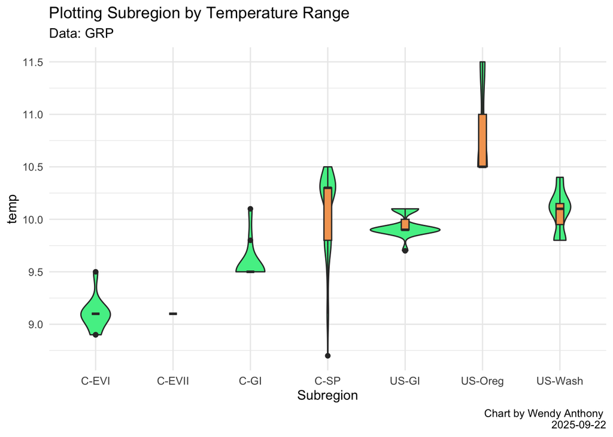

```r
GRP_all_site_temp_violin <- ggplot(results_projid_6,
      aes(x = Subregion, y = temp)) +
      geom_violin(fill = "seagreen2") +
      geom_boxplot(width = 0.1, fill = "sandybrown") +
      theme_minimal() + #get rid of grey background and tick marks
      theme(legend.position="none") + #remove legend
      theme(axis.text.x = element_text(vjust = 1, size = 9)) +
      labs(title='Plotting Subregion by Temperature Range',
           subtitle='Data: GRP',
           caption = "Chart by Wendy Anthony \n 2025-09-22")

GRP_all_site_temp_violin
```

```r
## ggplotly doesn't seem to work with violin plot??
    # ggplotly(tooltip = c("x", "y", "colour"), GRP_all_site_temp_violin) %>%
    #   config(displayModeBar = FALSE) %>% # This line disables the modebar
    #   layout(title = list(
    #     text = "GRP Annual Temperature by Subregion<br><sup>Data Source: GRP</sup>",
    #     y = 0.95), # Adjust vertical position if needed
    #     yaxis = list(title = 'Temperature (°C)'),
    #     annotations = list(x = 1, y = -0.1, text = "Chart by Wendy Anthony\n2025-09-22",
    #          showarrow = F, xref='paper', yref='paper',
    #          xanchor='right', yanchor= 'auto', xshift=0, yshift=0,
    #          font = list(size=8, color="grey"))
    #     )
```

## 6.4 violin plot - Precip

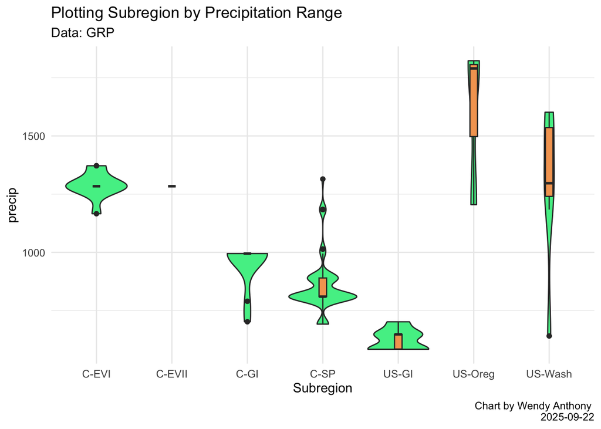

```r
GRP_all_site_prec_violin <- ggplot(results_projid_6,
      aes(x = Subregion, y = precip)) +
      geom_violin(fill = "seagreen2") +
      geom_boxplot(width = 0.1, fill = "sandybrown") +
      theme_minimal() + #get rid of grey background and tick marks
      theme(legend.position="none") + #remove legend
      theme(axis.text.x = element_text(vjust = 1, size = 9)) +
      labs(title='Plotting Subregion by Precipitation Range',
           subtitle='Data: GRP',
           caption = "Chart by Wendy Anthony \n 2025-09-22")

GRP_all_site_prec_violin
```

# 7 Leaflet Maps

## 7.1 Leaflet Site Map

```r
colnames(GRP_Site_data)
```

```
##  [1] "siteid"           "projectid"        "Site"             "Subregion"
##  [5] "Subregion.an"     "latitude"         "longitude"        "USDA.subsubclass"
##  [9] "soildepth"        "elevation"        "aspect"           "aridity"
## [13] "tcoldq"           "invasiveform"
```

```r
grp_site_data <- read.csv("data/GRP_all_site_data_sql.csv", header = TRUE, sep = ",")

# library(dplyr)
library(leaflet)

# Title control
# (Shackelford, et al., 2024). Global Restore Project. Restoration Futures Lab at the University of Victoria
 title <- '<p style="text-align: center; height: 18px; ">
<span style="font-size:9px;font-weight:bold; background-color: rgba(255, 255, 255, 0.9;");>Global Restore Project GOE Monitoring Sites</span><br>
<span style="font-size:6px;font-style:italic; background-color: rgba(255, 255, 255, 0.9;">(Data from Shackelford, et al., 2005-2022)</span></p>'

    # https://rstudio.github.io/leaflet/articles/markers.html
    # Create a palette that maps factor levels to colors
    #####
    # pal <- colorFactor(c("#d7191c", "#2c7bb6"), domain = c("Saanich Peninsula", "Gulf Islands"))
#     pal <- colorFactor(c("#7fc97f", "#beaed4", "#fdc086", "#ffff99", "#386cb0", "#f0027f", "#bf5b17"), domain = c("C-SP", "C-GI", "C-EVII", "C-EVI", "US-GI", "US-Wash", "US-Oreg"
# ))
 # #d95f02 orange; #7570b3 purple; #1b9e77 green
    pal <- colorFactor(c("#1b9e77", "#7570b3", "#7570b3", "#1b9e77", "#d95f02", "#d95f02", "#d95f02"), domain = c("C-SP", "C-GI", "C-EVII", "C-EVI", "US-GI", "US-Wash", "US-Oreg"))
GRP_site_map  <-  leaflet(grp_site_data) %>%
      addProviderTiles("Esri.WorldImagery") %>%
      addCircleMarkers(
        ~ longitude, ~ latitude,
        #
        color = ~pal(Subregion),
        # color = "yellow",
        weight = 1, # size of circle border
        stroke = TRUE, fillOpacity = 1, #fillOpacity = 0.5
        radius = 2,
        # OM_site_data$
        # "<b>Global Restore Project GOE Monitoring Sites</b>", "<br>", "<i>(Shackelford, et. al., 2005-2022)</i>", "<br><br>",
        popup = paste0(
          "<b>Site:</b> ", "<b>", grp_site_data$Site, "</b>",  "<br>",
          "<b>Subregion:</b> ", "<b>", grp_site_data$Subregion, "</b>",  "<br>",
          "<b>Project id:</b> ", "<b>", grp_site_data$projectid, "</b>",  "<br>",
          "<b>Landcover:</b> ", "<b>", grp_site_data$landcover, "</b>",  "<br>",
          "<b>Elevation:</b> ", "<b>", grp_site_data$elevation, "</b>",  "<br>",
          "<b>Aspect:</b> ", "<b>", grp_site_data$aspect, "</b>",  "<br>",
          "<b>Precipitation (mm):</b> ", "<b>", grp_site_data$precip, "</b>",  "<br>",
          "<b>Temperature (°C):</b> ", "<b>", grp_site_data$temp, "</b>"
          )) %>%

      setView(-123.44799, 48.64919, 10) %>%
      # add controls
      #  addMiniMap(width = 150, height = 150, zoomLevelOffset = -4) %>%
      addControl(title, position = "topright")

# Display map
GRP_site_map
```

[interactive chart not shown]

```r
# Save map
saveWidget(GRP_site_map, "output/GRP_site_map.html")
```